# R Crawler Week1

2016/10/12

## 什麼是網路爬蟲（Crawler）

- 把你平常開瀏覽器查資料的步驟，寫程式讓它自動完成！
- 大數據的時代，要如何「拿到資料」是最基本的起手式。

## 爬蟲的原理：**模仿** 人類的行為

目標：找出資料放在哪裡

1. 找出資料藏在哪個 request 裡
2. 觀察 request 的內容
3. 拿取資料

## 抓資料的基本流程：觀察、觀察、再觀察

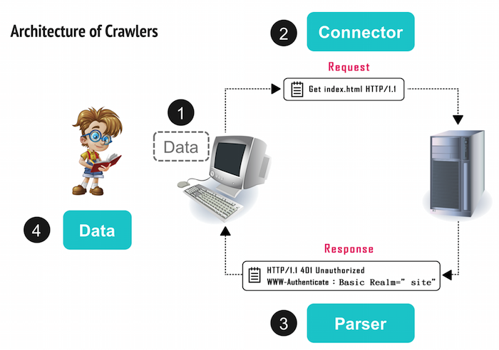

## 1. 找出資料藏在哪個 request 裡

練習：請用 Chrome 打開[批踢踢網頁版](https://www.ptt.cc/bbs/Gossiping/index.html)

1. 打開「開發人員工具」：右鍵 > 檢查
2. 切換到 **Network** 標籤
3. 按下 Record network log （確認紅燈亮著）、按下 All
4. 重新整理網頁
5. 找出資料藏身在哪一個 Request 裡面

## 1. 找出資料藏在哪個 request 裡

Requests 很多，找不到怎麼辦？

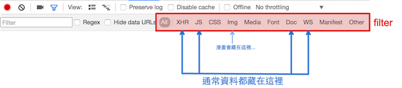

- 關掉 JavaScript：Chrome extension [Quick javascript swicher](https://chrome.google.com/webstore/detail/quick-javascript-switcher/geddoclleiomckbhadiaipdggiiccfje)
  - 資料還是跑得出來：Page-Render 資料和網頁一起回來
    - ⇒找 Doc [練習](http://db.cec.gov.tw/histQuery.jsp?voteCode=20160101T1A2&qryType=ctks)
  - 資料跑不出來：資料是用 JS Ajax 跑出來的
    - ⇒找 XHR、JS 或 WS [練習](http://ecshweb.pchome.com.tw/search/v3.3/?q=iphone)
- 猜：望文生義 request, r, q, ……

## 2. 觀察 request 的內容

[figure not shown]

## 2. 觀察 request 的內容

找到資料所在的 request 之後……

- 第一眼觀察重點：
  - Request URL
  - Request Method (GET/POST/…)
  - Status Code (200/302/404/…)
- 第二眼觀察重點：
  - Response Headers (location/set-cookie)
  - Request Headers (cookie/referer/user-agent/…)

## 2. 觀察 request 的內容

用「無痕模式」再一次打開[批踢踢網頁版](https://www.ptt.cc/bbs/Gossiping/index.html)

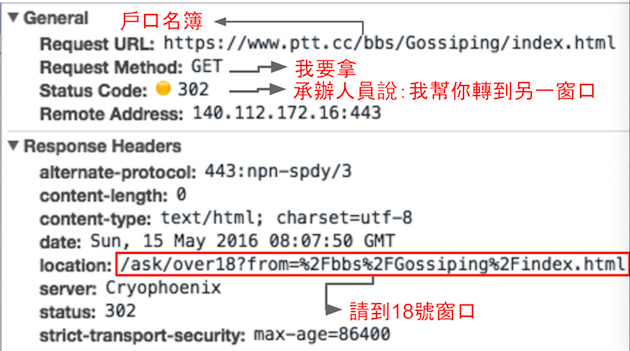

## 2. 觀察 request 的內容

轉址到 18 號窗口

[figure not shown]

## 2. 觀察 request 的內容

點選已滿 18 歲即成功進入

[figure not shown]

## 3. 拿取資料：用瀏覽器拿取資料

適用於比較單純的網站

**複習一下：**找到資料所在的 request 之後……

- 第一眼觀察重點：
  - Request URL
  - Request Method (GET/POST/…)
  - Status Code (200/302/404/…)

## Request URL：可以修改或串接

- 通常 URL 中就有變數藏在裡面
- URL?var1=val1&var2=val2 …

【修改 URL 變數】練習看看：

```
 + 2330台積電 ⇒ 2498宏達電

  https://tw.stock.yahoo.com/d/s/major_2330.html

 + 批踢踢網頁版首頁 ⇒  上一頁

  https://www.ptt.cc/bbs/Gossiping/index.html
```

## Request URL：可以修改或串接

- 通常 URL 中就有變數藏在裡面
- URL?var1=val1&var2=val2 …

【串接 URL】練習看看

```
 + 5284 公車路線

 http://5284.taipei.gov.tw/TextSearch.aspx

 + 公開資訊觀測站

 http://mops.twse.com.tw/mops/web/t51sb01
```

## Request Method

- GET (with query strings)
  - 可以直接以網址拿資料
  - 注意網址有時候會有參數

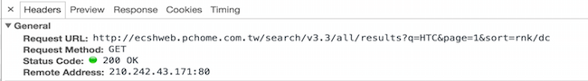

- POST
  - 除了提交網址之外，還要提交參數才能拿資料
  - 中文要注意編碼問題（特別是 Windows ）

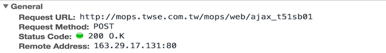

## 3. 拿取資料：用輔助工具拿取資料

[Advanced REST client](https://chrome.google.com/webstore/detail/advanced-rest-client/hgmloofddffdnphfgcellkdfbfbjeloo?hl=zh-TW&utm_source=chrome-ntp-launcher)

特別用在**須要通行證**的網站

- 再用[八卦板](https://www.ptt.cc/bbs/Gossiping/index.html)當例子

練習：

```
 + Mobile01 論壇

  http://www.mobile01.com/topiclist.php?f=520

 + 漫畫

  http://tw.ikanman.com/comic/1128/9771.html#p=3
```

## 拿取資料：Data Parser

要如何從 Data Page 中取出 Data？

### 用 DOM Selector (CSS/XPath)

## HTML 的樹狀結構與 DOM Selector

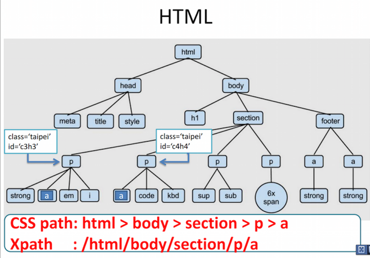

## HTML 的樹狀結構與 DOM Selector

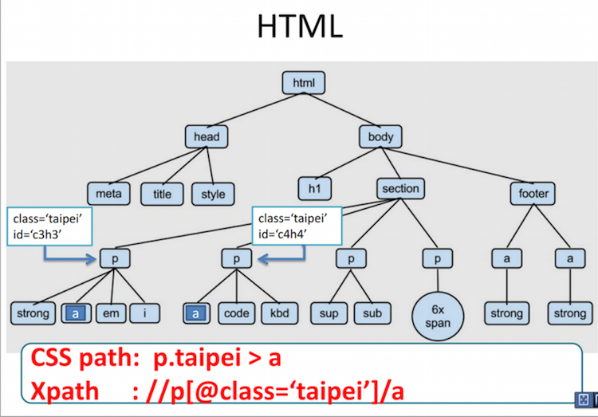

## HTML 的樹狀結構與 DOM Selector

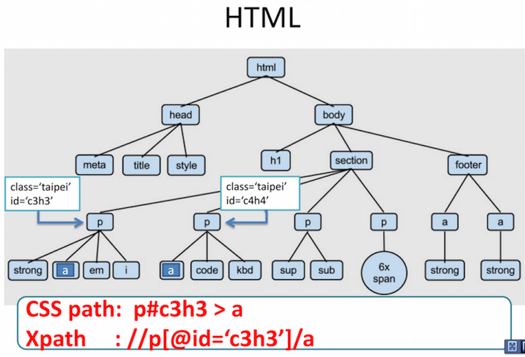

## DOM Selector： CSS Selector

安裝 Chrome extension [SelectorGadget](https://chrome.google.com/webstore/detail/selectorgadget/mhjhnkcfbdhnjickkkdbjoemdmbfginb/related?hl=zh-TW)

範例：[pchome商品](http://ecshweb.pchome.com.tw/search/v3.3/?q=apple)

Chrome Console: `document.querySelectorAll("CSS Selector")`

## DOM Selector： XPath Selector

安裝 Chrome extension [XPath Helper](https://chrome.google.com/webstore/detail/xpath-helper/hgimnogjllphhhkhlmebbmlgjoejdpjl?hl=zh-TW)

範例：[露天拍賣](http://search.ruten.com.tw/search/s000.php?enc=u&searchfrom=indexbar&k=apple&t=0)

Chrome Console: `$x("XPath Selector")`

## HOMEWORK

請安裝：

- 安裝 [RStudio](https://www.rstudio.com/products/rstudio/download3/)
- 執行 [install_packages.R](https://www.dropbox.com/s/68bs5yue0m7un2u/install_packages.R?dl=0) 以安裝所需套件

## HOMEWORK

對 R 不熟的人請閱讀：

- Quick-R：[data type](http://www.statmethods.net/input/datatypes.html)
- （中文）醫學統計與 R ：[第二章](http://web.ntpu.edu.tw/~cflin/Teach/R/R06C02DataBasic.pdf)、[第三章](http://web.ntpu.edu.tw/~cflin/Teach/R/R06EN03Object.pdf)
  - Note: 特別注意 vector, data frame, list 的使用方式

## HOMEWORK

有空的人可以：

- 玩玩 [CSS Selector](http://flukeout.github.io/)
- 玩玩 [Regular Expressions](https://regexone.com/)